# An improvement of classical estimation: Empirical Bayes

Brian Dong

04/01/2022

# 1 Intro

The classical estimation method such as MLE and method of moments were designed in an era when most experiments had a small number of random variables. But modern data sets can sometimes contain a very large amount of random variables and in these situations the classical estimation methods fall short. Empirical bayes estimation is a method that combines ideas from both bayesian and frequentist statistics to improve upon classical estimation methods in these situations. First, we will look at an example where classical estimates have obvious shortcomings. And then we will explain what the empirical Bayes estimate is and what situations its appropriate to use. Lastly, we will use an example to illustrate the benefits of using the empirical bayes estimator.

# 2 Example

Before we dive in to empirical bayes lets look at a situation where traditional methods are insufficient and then we will show how the empirical Bayes estimate is better. We will be using NBA free throw data with our goal being to predict a players free throw percentage in the following season. Let us first look at a histogram of all the players free throw percentage.

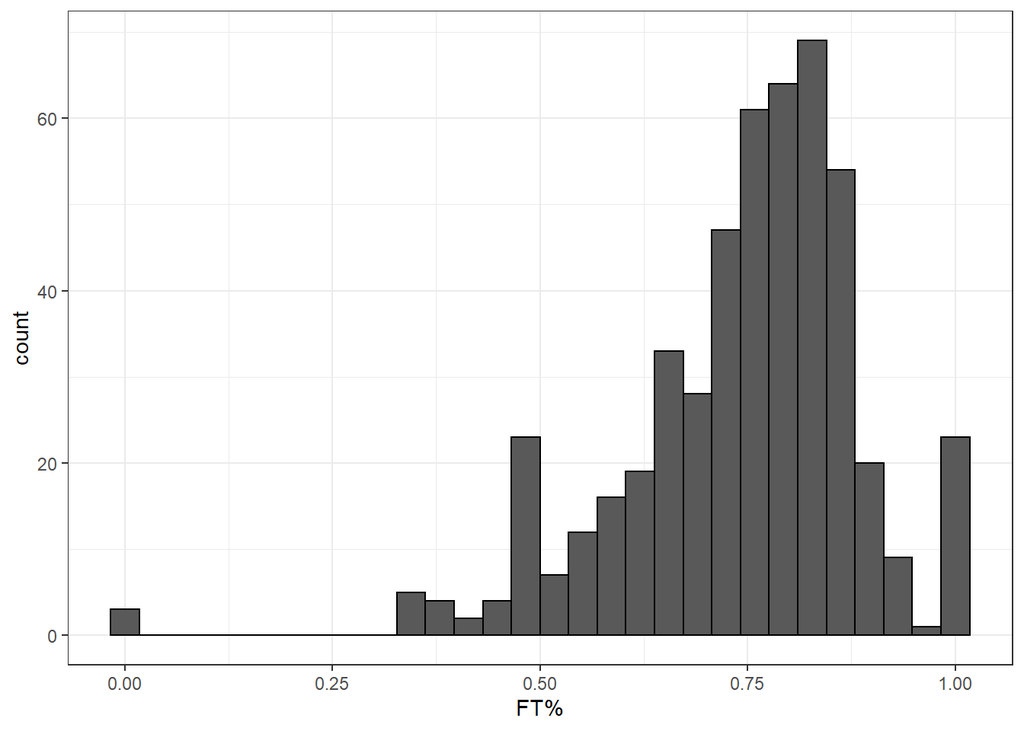

```r
library(SportsR)
library(tidyverse)
library(VGAM)
data <- load_nba("total",2020) %>%
  select(Player,FT,FTA,`FT%`) %>%
  group_by(Player) %>%
  summarise(FT = sum(FT), FTA= sum(FTA),
            `FT%` = FT / FTA) %>%
  arrange(-`FT%`) %>%
  filter(FTA > 0)
ggplot(data,aes(x = `FT%`)) + geom_histogram(color = "black") + theme_bw()
```

There seems to be an surprisingly high concentration of players making every single one of their free throws. Lets see who these players are and try and figure out what makes them so successful.

```r
data
```

```
## # A tibble: 504 x 4
##    Player               FT   FTA `FT%`
##    <chr>             <dbl> <dbl> <dbl>
##  1 Charlie Brown Jr.     5     5     1
##  2 Chris Chiozza        10    10     1
##  3 Dusty Hannahs         2     2     1
##  4 Eric Mika             2     2     1
##  5 J.R. Smith            2     2     1
##  6 Jalen Lecque          2     2     1
##  7 Jared Dudley          2     2     1
##  8 Jarred Vanderbilt     4     4     1
##  9 Jarrod Uthoff         4     4     1
## 10 Joe Chealey           2     2     1
## # ... with 494 more rows
```

It seems the key to having a high free throw percentage is to take a very low number of shows and hope you get lucky. Even though a player has hit 100% of his free throws we know that it is very unlikely he will keep shooting at this rate in the future. By looking at the histogram above one can see that the most NBA players will make around 70% - 80% of there free throws. This is not taken into account when using the classical MLE estimate which is how we end up with a decent portion of players having a predicted free throw percentage of 100%. Instead of using the MLE we could perhaps use a method that accounts for the fact that most players end up in the 70%-80% range. This is exactly what empirical bayes does and why it improves upon the MLE.

# 3 Empirical Bayes

What makes empirical bayes unique is that it borrows ideas from both frequentist and bayesian statistics. It is used when there large number of random variables that come from the same class of distribution, but with each variable having its own parameters. For example, the number of free throws made by an NBA player has a binomial distribution, but each player has their own unique success probability. So, lets say we have $p$ players then we can write the distribution of each player has

$y_i | \theta_i \sim Bin(n_i,\theta_i)$

where $\theta_i$ is that players probability of making a free throw. An assumption we make in empirical bayes is that the all the parameters for each variable come from the same distribution. In essence we are assuming that the parameters for each variable share the same underlying structure. In our example, since our data has a binomial distribution, we could use the beta distribution to model the success probability for each player. So, if we had probabilities $\theta_1, \theta_2, ..., \theta_p$ then

$\theta_1, \theta_2, ..., \theta_p \sim Beta(\alpha,\beta)$

Now this is starting to look like a simple bayesian problem. And one could use their own prior belief to choose the $\alpha$ and $\beta$ values. But, this is where the empirical bayes method diverges from traditional bayesian inference. Empirical bayes estimates the prior parameters from the data itself. What we do is use all the data from each variable and use it to estimate the prior. This is how empirical bayes uses data from other variables to estimate the parameters of one variable. We can do that in many ways, but the most common method is to calculate the marginal distribution of $y$ which in this case is

$y_i \sim {n \choose y} \frac{B(k + \alpha, n - y + \beta)}{B(\alpha,\beta)}$

where $B(\alpha,\beta)$ is the beta function. The above distribution is called the beta binomial distribution. Once one knows the marginal any traditional point estimator can be used to estimate the prior parameters such as MLE or method of moments. Then we can calculate the posterior distribution for each variable. In our example the posterior is a beta distribution with the parameters seen below.

$\theta_i | y_i \sim Beta(\alpha + y_i, n + \beta - y_i)$

Now, one may ask why how using data from other independent variables can improve the estimate of a variables parameters. To see how this improves upon the classical MLE estimate lets look at the expected value of our posterior distribution. The expected value comes out to

$\hat{\theta}_{i} = \frac{\beta + \alpha}{n + \beta + \alpha} \frac{\alpha}{\beta + \alpha} + \frac{n}{n + \beta + \alpha} \frac{y_i}{n}$

Which is the weighted average of the prior mean and the sample average so when $n$ is small the prior mean dominates and as n increases the sample average comes to dominate. So before when we looked at the best shooters who had only taken a small number of shots our empirical bayes estimate would in effect be very close to the prior mean. Which makes sense since they have taken a small number of shots that there is notenough evidence to conclude if they are below or above average. So what the empirical bayes estimator is doing is shrinking the MLE estimate to the average of the prior. An intuitive way to think about it is that it is anticipating the regression to the mean. And variables with a smaller number of observations are going to be shrunk much more severally than those with a larger number of observations.

One advantage of the empirical bayes estimate is its flexibility. As we just showed what empirical bayes does is shrink the MLE estimate towards the prior mean. But what if there was a variable $X$ that we believed had a linear relationship with the mean of each variable. To illustrate how we can use $X$ in empirical bayes lets look at the normal model with known variance. The distributions needed for this model are

$y_i | \theta \sim N(\theta_i,\sigma_i^2)$

$\theta_1,..,\theta_p \sim N(\mu,\tau^2)$

$y_i \sim N(\mu,\sigma_i^2 + \tau^2)$

Now to account for $X$’s linear relationship with $y$ we can write the marginal and prior distributions as

$\theta_1,..,\theta_p \sim N(\beta_0 + X\beta_1,\tau^2)$

$y_i \sim N(\beta_0 + X\beta_1,\sigma_i^2 + \tau^2)$

Then we can estimate $\beta_0$ and $\beta_1$ using the traditional OLS estimates. Doing this causes the empirical bayes estimate to be shrunk towards the linear regression line instead of the prior mean. This is a simple extension, but extensions like these show the power of the empirical bayes estimator.

Much of this section has been dedicated to understanding empirical bayes, but does it actually improve upon the MLE estimates? Surprisingly, the empirical bayes estimate will always have a lower group MSE error than MLE estimates when the number of variables is greater than three. This phenomena is called Steins paradox, and while it is always true that empirical bayes estimator has a lower group MSE then the MLE for some individual variables the estimate will be worse then the MLE. That is the trade off when using the empirical bayes estimator.

# 4 Application

Now that we know the empirical bayes method let us apply it to the free throw data we looked at earlier. First, we will estimate the parameters of our prior distribution from the marginal distribution of $y$ which we saw in the last section was the beta binomial distribution. The code below uses the `optim` function to find the MLE estimates of the prior parameters.

```r
ll <- function(par) {
  -sum(dbetabinom.ab(data$FT, data$FTA, par[1], par[2], log = TRUE))
}

prior <- optim(par = c(7,10),ll)
prior$par
```

```
## [1] 18.015133  5.846009
```

So our estimates for $\alpha$ and $\beta$ are 18.0151331 and 5.8460091 respectively. Which would give us a prior mean of 0.7549988. Which lines up with what our earlier histogram showed. So when we apply the empirical bayes method every players estimate will be pulled towards 0.7549988. Now lets use these values of $\alpha$ and $\beta$ to calculate each players empirical bayes estimate.

```r
data$eb_estimate <- (prior$par[1] + data$FT) / (prior$par[1] + prior$par[2] + data$FTA)
data
```

```
## # A tibble: 504 x 5
##    Player               FT   FTA `FT%` eb_estimate
##    <chr>             <dbl> <dbl> <dbl>       <dbl>
##  1 Charlie Brown Jr.     5     5     1       0.797
##  2 Chris Chiozza        10    10     1       0.827
##  3 Dusty Hannahs         2     2     1       0.774
##  4 Eric Mika             2     2     1       0.774
##  5 J.R. Smith            2     2     1       0.774
##  6 Jalen Lecque          2     2     1       0.774
##  7 Jared Dudley          2     2     1       0.774
##  8 Jarred Vanderbilt     4     4     1       0.790
##  9 Jarrod Uthoff         4     4     1       0.790
## 10 Joe Chealey           2     2     1       0.774
## # ... with 494 more rows
```

The output above shows the same players we looked at earlier who had the highest free throw percentage out of all players. But, their empirical bayes estimates are much lower and much closer to the prior mean. These are much more reasonable estimates since these players have so attempted such a small number of shots that we cannot conclude if they are below or above average free throw shooters. Now that every players free throw percentage has been shrunk let us now see which players we estimate are the best free throw shooters in the league.

```r
data %>% arrange(-eb_estimate)
```

```
## # A tibble: 504 x 5
##    Player              FT   FTA `FT%` eb_estimate
##    <chr>            <dbl> <dbl> <dbl>       <dbl>
##  1 Devin Booker       468   509 0.919       0.912
##  2 Khris Middleton    208   227 0.916       0.901
##  3 Brad Wanamaker     126   136 0.926       0.901
##  4 Tony Snell          32    32 1           0.895
##  5 Chris Paul         253   279 0.907       0.895
##  6 Bojan Bogdanovic   250   277 0.903       0.891
##  7 Kyrie Irving        94   102 0.922       0.890
##  8 Duncan Robinson     67    72 0.931       0.887
##  9 Stephen Curry       26    26 1           0.883
## 10 Danilo Gallinari   266   298 0.893       0.882
## # ... with 494 more rows
```

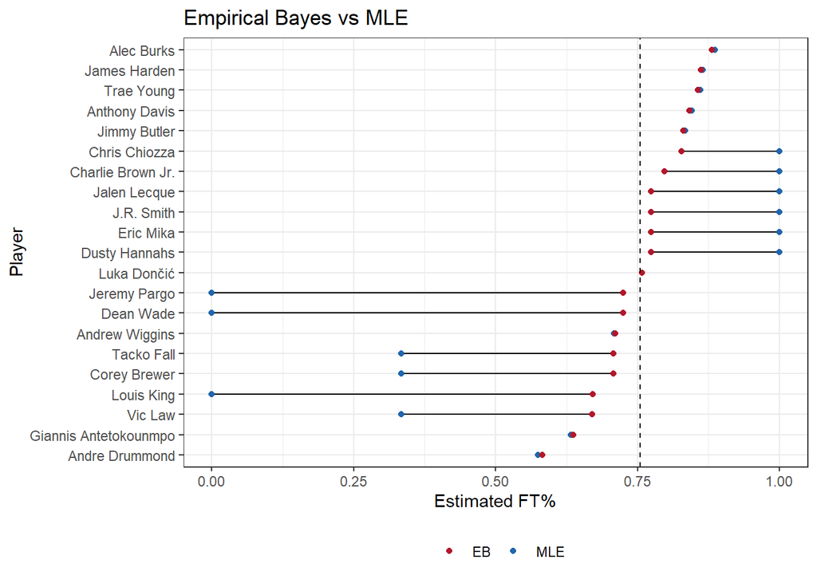

Now let us compare the accuracy of our empirical bayes estimator to the MLE. Lets look at the players results from the following season and calculate the mean squared error of the MLE estimate and the empirical bayes estimate.

```r
mse <- load_nba("total",2021) %>%
  select(Player,FT,FTA,`FT%`) %>%
  left_join(data,by=  c("Player" = "Player")) %>%
  mutate(eb_se = (eb_estimate - `FT%.x`)^2,
         mle_se = (`FT%.y`-  `FT%.x`)^2) %>%
  summarise(eb_mse = mean(eb_se,na.rm = T),
            mle_mse = mean(mle_se,na.rm = T))
mse
```

```
## # A tibble: 1 x 2
##   eb_mse mle_mse
##    <dbl>   <dbl>
## 1 0.0168  0.0231
```

The empirical bayes estimate has a 27% percent decrease in mse compared to the classical MLE. Showing that in situations with a large amount of variables the empirical bayes estimator can drastically improve ones estimate.

# 5 Conclusion

By taking elements from bayesian and frequentist method empirical bayes is able to get better point estimates when there is a large number of variables. And data sets with a large number of variables are much more common then they were in the past. And while so far I have only showed the usefulness of empirical bayes as frequentist point estimator it can be treated as a bayesian method as well. Where each variable has its own posterior distribution. One thing to keep in mind is that some bayesians do not like empirical bayes since the prior is being estimated from the data not from ones prior belief. Another issue to keep in mind is that traditional variance formulas are underestimates of the true variance since they do not take into account the variability in the MLE estimates of the prior. Despite these issues empirical bayes estimates can drastically improve accuracy over the MLE estimates in situations with a large number of variables.

# 6 References

Casella, George. “An Introduction to Empirical Bayes Data Analysis.” The American Statistician, vol. 39, no. 2, 1985, p. 83., https://doi.org/10.2307/2682801.

Efron, Bradley. Large-Scale Inference: Empirical Bayes Methods for Estimation, Testing, and Prediction. Cambridge University Press, 2013.

Robinson, David. “Understanding Empirical Bayes Estimation (Using Baseball Statistics).” Variance Explained, 1 Oct. 2015, http://varianceexplained.org/r/empirical_bayes_baseball/.